# Introduction to data

**Your reproducible lab report:** Before you get started, you can access the template Rmd file by clicking File > New File > R Markdown > From template > R Markdown Lab report

Some define statistics as the field that focuses on turning information into knowledge. The first step in that process is to summarize and describe the raw information - the data. In this lab we explore flights, specifically all 162,049 domestic flights that departed from the largest airports in the Pacific Northwest, Seattle-Tacoma and Portland International Airports, in 2014. We will generate simple graphical and numerical summaries of data on these flights and explore delay times. As this is a large data set, along the way you’ll also learn the indispensable skills of data processing and subsetting.

To start the lab you’ll need to load in the packages that we’ll be using today.

```r
library(oilabs)
library(pnwflights14)
library(ggplot2)
library(dplyr)
```

**A note on expectations:** For each Exercise and On Your Own question you answer, include any relevant output (tables, summary statistics, plots) in your answer. Doing this is easy! Just place any relevant R code in a code chunk, and hit Knit HTML.

### Data

The [Bureau of Transportation Statistics](http://www.rita.dot.gov/bts/about/) (BTS) is a statistical agency that is a part of the Research and Innovative Technology Administration (RITA). As its name implies, BTS collects and makes available transportation data, such as the flights data we will be working with in this lab.

We begin by loading the data set into the R workspace. After launching RStudio, enter the following command in the console.

```r
data(flights)
```

The data set `flights` that shows up in your workspace is a *data matrix*, with each row representing an *observation* and each column representing a *variable*. R calls this data format a **data frame**, which is a term that will be used throughout the labs.

To view the names of the variables, type the command

```r
names(flights)
```

This returns the names of the variables in this data frame. The **codebook** (description of the variables) is included below.

- `year`, `month`, `day`: Date of departure
- `dep_time`, `arr_time`: Departure and arrival times, local timezone.
- `dep_delay`, `arr_delay`: Departure and arrival delays, in minutes. Negative times represent early departures/arrivals.
- `carrier`: Two letter carrier abbreviation.
  - `9E`: Endeavor Air Inc.
  - `AA`: American Airlines Inc.
  - `AS`: Alaska Airlines Inc.
  - `B6`: JetBlue Airways
  - `DL`: Delta Air Lines Inc.
  - `EV`: ExpressJet Airlines Inc.
  - `F9`: Frontier Airlines Inc.
  - `FL`: AirTran Airways Corporation
  - `HA`: Hawaiian Airlines Inc.
  - `MQ`: Envoy Air
  - `OO`: SkyWest Airlines Inc.
  - `UA`: United Air Lines Inc.
  - `US`: US Airways Inc.
  - `VX`: Virgin America
  - `WN`: Southwest Airlines Co.
  - `YV`: Mesa Airlines Inc.
- `tailnum`: Plane tail number
- `flight`: Flight number
- `origin`, `dest`: Airport codes for origin and destination. (Google can help you with what code stands for which airport.)
- `air_time`: Amount of time spent in the air, in minutes.
- `distance`: Distance flown, in miles.
- `hour`, `minute`: Time of departure broken into hour and minutes.

A very useful function for taking a quick peek at your data frame, and viewing its dimensions and data types is `str`, which stands for **str**ucture.

```r
str(flights)
```

The `flights` data frame is a massive trove of information. Let’s think about some questions we might want to answer with these data:

- How delayed do flights headed to a particular destination tend to be?
- How do departure delays vary over different months?
- Which of the two major PNW airports has the best on time percentage for departing flights?

### Seven verbs

The `dplyr` package offers seven verbs (functions) for basic data manipulation:

- `filter()`
- `arrange()`
- `select()`
- `distinct()`
- `mutate()`
- `summarise()`
- `sample_n()`

We will use some of these functions in this lab, and learn about others in a future lab.

## Analysis

### Departure delays to Portland (PDX)

We can examine the distribution of departure delays of all flights with a histogram.

```r
qplot(x = dep_delay, data = flights, geom = "histogram")
```

This function says to plot the `dep_delay` variable from the `flights` data frame on the x-axis. It also defines a `geom` (short for geometric object), which describes the type of plot you will produce.

Histograms are generally a very good way to see the shape of a single continuous variable, but that shape can change depending on how the data is split between the different bins. You can easily define the binwidth you want to use:

```r
qplot(x = dep_delay, data = flights, geom = "histogram", binwidth = 15)
qplot(x = dep_delay, data = flights, geom = "histogram", binwidth = 150)
```

1. How do these three histograms with the various binwidths compare?

If we want to focus on departure delays of flights leaving from PDX only, we need to first `filter` the data for flights leaving PDX (`origin == "PDX"`) and then make a histogram of only departure delays of only those flights.

```r
pdx_flights <- filter(flights, origin == "PDX")
qplot(x = dep_delay, data = pdx_flights, geom = "histogram")
```

**Logical operators:** Filtering for certain observations (e.g. flights from a particular airport) is often of interest in data frames where we might want to examine observations with certain characteristics separately from the rest of the data. To do so we use the `filter` function and a series of **logical operators**. The most commonly used logical operators for data analysis are as follows:

- `==` means “equal to”
- `!=` means “not equal to”
- `>` or `<` means “greater than” or “less than”
- `>=` or `<=` means “greater than or equal to” or “less than or equal to”

We can also obtain numerical summaries for these flights:

```r
summarise(pdx_flights,
          mean_dd = mean(dep_delay, na.rm = TRUE),
          sd_dd = sd(dep_delay, na.rm = TRUE),
          n = n())
```

Note that in the `summarise` function we created a new data frame with only one row and three columns. The names of these new columns are user defined, like `mean_dd`, `sd_dd`, `n`, and you could customize these names as you like (just don’t use spaces in your names). Calculating these summary statistics also require that you know the function calls. Note that `n()` reports the sample size. In terms of the unusual spacing - here we have a single line of code continued across four lines - you’re welcome to add line breaks after commas to help improve the readability of your code.

**Summary statistics:** Some useful function calls for summary statistics for a single numerical variable are as follows:

- `mean`
- `median`
- `sd`
- `var`
- `IQR`
- `range`
- `min`
- `max`

We can also filter based on multiple criteria. Suppose we are interested in flights headed from Portand to San Francisco (SFO) in February:

```r
sfo_feb_flights <- filter(pdx_flights, dest == "SFO" & month == 2)
```

Note that we can separate the conditions using `&` if we want flights that are both headed to SFO **and** in February. If we are interested in all flights that either headed to SFO **or** in February we can use the `|` instead of the `&`

1. Create a new data frame that includes flights headed to SFO in February, and save this data frame as `sfo_feb_flights`. How many flights meet these criteria?
2. Describe the distribution of the **arrival** delays of these flights using a histogram and appropriate summary statistics. **Hint:** The summary statistics you use should depend on the shape of the distribution.

### The Pipe

By now you’ve noticed that most lines of R code looks like `new_object <- function(argument1, argument2)`. While that is a straightforward paradigm for a programming language, it can get clunky if we want to do many operations (read: functions) on the same data set.

At the start of this lab we did two sequential operations on the `flights` data frame. First, we `filter`ed the rows to only keep those that left from PDX and saved it as a new data frame. Second, we used `summarise` to calculate some summary statistics on that data frame. These two functions can be integrated into a single chain of R code using an operator called the *pipe*.

```r
flights %>%
  filter(origin == "PDX") %>%
  summarise(mean_dd = mean(dep_delay, na.rm = TRUE),
            sd_dd = sd(dep_delay, na.rm = TRUE),
            n = n())
```

1. Compare the arguments to `filter` and `summarise` with the arguments that you used when you first did this as two separate operations. What has changed?

If the `%>%` symbol is called the pipe, the chain of R code above can be thought of as a data pipeline. It reads quite clearly: *take the flights data set, first filter it so that all flights originate at PDX, then summarize those flights by taking the mean departure delays, the sd of the departure delays, and then count how many there are*. All that the pipe does is take the output of the thing upstream and sends it into the next function as the first argument. Both piped and pipeless approaches work, but we encourage creating data pipelines when you need to streamline a task that has multiple steps.

### Groupwise Operations

Another very powerful functionality is being able to quickly calculate summary statistics for various groups in your data frame. For example, we can modify the summarise command using the `group_by` function to get the same summary stats for each origin airport:

```r
flights %>%
  group_by(origin) %>%
  summarise(mean_dd = mean(dep_delay, na.rm = TRUE),
            sd_dd = sd(dep_delay, na.rm = TRUE),
            n = n())
```

Here, we first grouped the data by `origin`, and then calculated the summary statistics for each group.

1. Calculate the median and interquartile range for `arr_delay`s of flights in the `sfo_feb_flights` data frame, grouped by carrier. Which carrier has the most variable arrival delays?

### Departure delays over months

Which month would you expect to have the highest average delay departing from PDX?

Let’s think about how we would answer this question:

- First, calculate monthly averages for departure delays. With the new language we are learning, we need to
  - `filter` origin to correspond to PDX (or use the `pdx_flights` data frame)
  - `group_by` months, then
  - `summarise` mean departure delays.
- Then, we need to `arrange` these average delays in `desc`ending order

```r
flights %>%
  filter(origin == "PDX") %>%
  group_by(month) %>%
  summarise(mean_dd = mean(dep_delay, na.rm = TRUE)) %>%
  arrange(desc(mean_dd))
```

1. Which month has the highest average departure delay? What about the highest median departure delay? Which of these measures is more reliable for deciding which month(s) to avoid flying if you really dislike delayed flights.

We can also visualize the distributions of departure delays across months using side-by-side box plots:

```r
qplot(y = dep_delay, x = factor(month), data = flights, geom = "boxplot")
```

There is some new syntax here: We want departure delays on the y-axis and the months on the x-axis to produce side-by-side box plots. Side-by-side box plots require a categorical variable on the x-axis, however in the data frame `month` is stored as a numerical variable (numbers 1 - 12). Therefore we can force R to treat this variable as categorical, what R calls a **factor**, variable with `factor(month)`.

## On Your Own

- Mutate the data frame so that it includes a new variable that contains the average speed, `avg_speed` traveled by the plane for each flight (in mph). **Hint:** Average speed can be calculated as distance divided by number of hours of travel, and note that `air_time` is given in minutes.
- What is the tail number of the plane with the fastest `avg_speed`? **Hint:** If you just want to show the `avg_speed` and `tailnum` and none of the other variables, use the select function at the end of your pipe to select just these two variables with `select(avg_speed, tailnum)`. You can google this tail number to find out more about the aircraft.
- Make a scatterplot of `avg_speed` vs. `distance`. Describe the relationship between average speed and distance. **Hint:** Use `geom = "point"`.
- What R code using functions in the `dplyr` package on the `flights` dataset is necessary to produce the table below the plot on 5.? Review the names used earlier to understand the variable choices here. **What information does this table provide about the data set?**
- Replicate the following plot. **Hint:** The data frame plotted only contains flights from American Airlines, Delta Airlines, and United Airlines, and the points are `color`ed by `carrier`. Once you replicate the plot, determine (roughly) what the cutoff point is for departure delays where you can still expect to get to your destination on time.

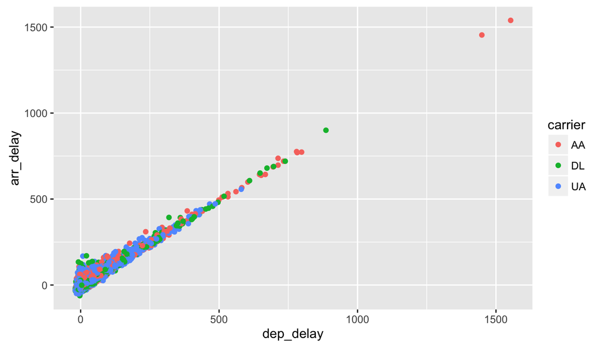

```
## Source: local data frame [11 x 3]
##
##    carrier max_dd IQR_ad
## 1       AA   1553     23
## 2       AS    866     18
## 3       B6    365     23
## 4       DL    886     17
## 5       F9    815     20
## 6       HA    878     27
## 7       OO    677     16
## 8       UA    580     23
## 9       US    711     17
## 10      VX    358     17
## 11      WN    712     21
```